# news-category-dataset-deep-learning-algorithms

title: Text Classification on News Texts description: Semester Project for the academic course of "Deep Learning" date: 2024 author: name: Evangelia Tsakanika affiliation: Department of Computer Science and Biomedical Informatics, University of Thessaly

### **Abstract**

The need to manage large amounts of data, make useful inferences and deepen the fields of Artificial Intelligence, such as the field of Text Classification, are undoubtedly some of the most important goals of this science. This paper aims to categorize a set of news texts based on their content and title using basic Text Classification algorithms. More specifically, a study of the "News_Category Dataset" from the "kaggle" website, a dataset which includes 209,528 news text records collected from the global news website "Huffpost", was carried out. This dataset has for each record/text, various information such as the title and a short description of the text, its content-based genre, its link to the website as well as its author(s) and the date of publication. In total, the records are for published articles from 2012 to 2018. Based on the above study, the creation of an Artificial Neural Network using Deep Learning techniques is presented, which will be able to perform this task. The Neural Networks implemented in this work are RNN architecture, LSTM (Long Short-Term Memory) and Naive Bayes categorizer using TF-IDF technique. In total, the dataset contains 42 different categories of news texts, which are derived based on the content of each text. To process the data, 42 separate numeric labels were created to represent each category individually and the appropriate datasets were created for training and subsequent model testing. Within this paper, the data preprocessing techniques followed, the corresponding codes for the implementation of the neural networks and the overall results of the above approaches are presented.

### **Literature Review**

Research on Text Classification has occupied many scientists and research communities for many decades. More specifically, people have always sought to classify and categorize their documents, books and general texts available to them in order to organize them. With the development of Artificial Intelligence and the ever-increasing rate of textual data creation, there has been a strong need to effectively manage such data and make valuable inferences. This resulted in the development of the problem of "Text Classification" or as it is referred to in the world literature "Text Classification".

"Text Classification", is an issue of both Machine and Deep Learning and aims to categorize documents into predefined, already known categories based on the content and idea it presents. In order to achieve this purpose, several specialized "Text Classifiers" are used which offer to organize, categorize, group and generally process texts. "Text Classification" is one of the most basic techniques and methodologies of the scientific discipline of "Natural Language Processing" (NLP). Some of the key advantages of "Text Classification" are (a) increased and accurate model performance, (b) the ability to process data in real-time and (c) the provision of capabilities to analyze large and complex volumes of real data.

The problem of "Text Classification" has significantly engaged and inspired many scientists as well as diverse research communities around the world. More specifically, in terms of Health Sciences and Healthcare, it is worth mentioning its contribution to the identification of significant biomedical entities (bNERs) within electronic patient documents (Ahmad et al., 2023). Complementarily, this technique finds excellent application in the analysis and visualization, through statistical methods, of a set of diseases by analyzing specific symptoms and parameters from Health Records Data (Hassan et al, 2024). In addition to the above, however, it is necessary to mention the contribution of "Text Classification" in the categorization of cancer patient documents and their analysis (Edara et al., 2019) and additionally in the prognosis of breast cancers and their metastasis (Botlagunta et al, 2023). Another, important use of "Text Classification" is in the detection of fake news-fake news (Zhang et al., 2023 & Capuano et al., 2023) as well as additionally in the validation and clustering of political news for further analysis and deepening (Osnabrügge et al., 2021). Finally, another important and fast-growing research discipline, with the user of "Document Categorization", is the analysis of texts found in social media applications and the interpretation of their content. More specifically, researches have relied on text classification and graphical visualization of text parameters to perform such studies (Ali et al., 2023), and even artificial neural networks of BERT architecture have been implemented in order to achieve the detection of offensive comments in the context of texts in social media (Wadud et al, 2022). In addition, it is worth mentioning the useful contribution of the studied method in facilitating business and its impact through social media studies (Kanan et al., 2022).

### **Brief Algorithm Description**

In the context of this work, in order to achieve the correct categorization of the articles of the studied dataset, some of the most widely used model architectures in the field of Text Classification were applied.

Initially, the **RNN-Recurrent Neural Networks** architecture was applied. RNN neural networks are one of the most basic classes of neural networks, which are specifically designed to process sequential data, which makes them particularly effective for applications such as text classification. RNN neural networks, unlike other network architectures, have directed cyclic connections between their nodes in order to allow the network to maintain a form of memory of its previous inputs as well as its internal states. This feature, makes RNNs capable of capturing and exploiting temporal dependencies in conjunction with the information within the sequences contained in the data under study, which is essential for understanding and creating coherent text. However, formal RNNs often face difficulties such as vanishing gradients, which pose challenges when training on large sequences.

Then, the **LSTM-Long Short-Term Memory** architecture was implemented, which is an extension of the RNN neural network architecture and is distinguished for its suitability in processing continuous sequence data, such as for example character sequences within some text, time series or even speech audio signals. LSTM models have 4 types of unit-units based on their architecture:

1. First, there is the so-called cell-cell which has the ability to store data,
2. Next, the input-input gate is found, which includes a sigmoidal function and based on it the appropriate input is selected,
3. Then the forget-forget gate is found, through which and the specific sigmoidal functions it contains, all the information of the data that is not needed in the analysis of the model is extracted.
4. And finally we find the output-output gate, through which the output of the model is decided based on both its input and the values stored in its memory.

The **Naive Bayes** algorithm is a fundamental probabilistic classification algorithm based on Bayes' theorem, which is widely used for text classification tasks due to its simplicity and efficiency. The algorithm operates under the assumption of conditional independence, i.e. it assumes that the presence of a particular feature in a class is independent of the presence of any other feature. Naive Bayes has proven to be highly effective and accurate in various applications, such as spam detection and sentiment analysis. It can be implemented in variants, including Multinomial, Bernoulli and Gaussian classifiers, each of which is adapted to different types of data distributions. The computational efficiency of the algorithm and the relatively low requirements for training data make it particularly suitable for large-scale text classification problems.

### **Metrics for the Evaluation of Results**

1. **Confusion Matrix**

Each row of the confusion matrix represents each category contained in the studied dataset while each column represents each predicted category. More specifically, this method aims to highlight the prediction efficiency of the models in this paper.

The **diagonal** of the model, recognises the categories that the model predicted best and most accurately. Consequently, the larger the value of each cell of the diagonal of the confusion dyad, the better the model's prediction for the respective categories. All other values that do not belong to the diagonal of the table are for the categories in which the prediction was wrong. The larger the value of each cell, implies the greater the incorrect prediction.

2. **ROC Curve**

Based on this metric, the accuracy of the model in predicting and classifying the 42 categories is observed.

Each **Curve** represents each individual category and more specifically the relationship between the True Positive Rate (TPR) and False Positive Rate (FPR) corresponding to that category. The diagonal of the method, represents the measure used to evaluate the forecasting efficiency of the model. Therefore, if a curve is formed below the diagonal area, it is inferred that it is not very effective in predicting it, while if a curve is formed above the diagonal area, it is inferred that it successfully predicts the category it represents. Curves with values closer to 1 also imply better prediction of the model.

### **Necessary Data Pre-processing**

Initially, a prerequisite for the implementation of the neural network architectures presented in this paper is the declaration of the appropriate libraries and packages of the Python programming language. The basic Python language libraries are declared and used: tensorflow, keras, matplotlib, pandas and numpy.

```python
# Importing the necessary libraries and packages
import tensorflow as tf
print(tf.__version__)

import keras as kr
print(kr.__version__)

import matplotlib as pltb
import matplotlib.pyplot as plt
print(pltb.__version__)

import pandas as pd
print(pd.__version__)

import numpy as np
print(np.__version__)

import csv

import nltk
import re

# Download stopwords from nltk
nltk.download('stopwords')
from nltk.corpus import stopwords

import sklearn
print(sklearn.__version__)

from sklearn.model_selection import train_test_split
from tensorflow.keras.preprocessing.text import Tokenizer
from tensorflow.keras.preprocessing.sequence import pad_sequences

from tensorflow.keras.models import Sequential
from tensorflow.keras.layers import Embedding, LSTM, SimpleRNN, Dense, Dropout
from sklearn.preprocessing import LabelEncoder
from tensorflow.keras.utils import to_categorical

from sklearn.preprocessing import LabelEncoder
from sklearn.feature_extraction.text import TfidfVectorizer

from sklearn.naive_bayes import MultinomialNB
from sklearn.metrics import accuracy_score, classification_report
import seaborn as sns

from sklearn.metrics import roc_curve, auc, confusion_matrix, ConfusionMatrixDisplay, roc_auc_score
from sklearn.preprocessing import label_binarize

from sklearn.multiclass import OneVsRestClassifier
```

Then, follows the code part, in which by using the function **"pd.read_jason "** the correct reading of the file is achieved, the loading of data into the code and most importantly, the creation of a dataframe that includes the whole dataset to be studied, for its better management in the neural networks to be used.

```python
# Ανάγνωση του json αρχείου και φόρτωση των δεδομένων

news = pd.read_json('C:\\Users\\USER\\Desktop\\University\\Deep_Learning_Project_2024\\News_Category_Dataset_v3.json', lines=True)
```

The following code fragment contains basic commands for displaying attributes of a dataset. More specifically, the **"news.head "** function is used to display the first 5 records of the dataset, while the **"news.info "** command is used to display additional information regarding the data.

```python
# Display information about the dataset

news.head()
news.info()
```

In the following code fragment, one of the **basic preprocessing** procedures of the studied dataset is performed. An epilogue column named **'combined_text'** is created, which includes both the title and description of each record/text in the dataset. This approach is used to isolate the desired data segments, based on which the type of text will be detected and properly categorized, which is the goal of this paper.

```python
# Create a new column ('combined_text') containing merged text
# of the 'headline' and 'short description' columns of each record/text


news['combined_text'] = news['headline'] + ' ' + news['short_description']
```

Through the creation of a .txt file, to which the output data of the print commands was redirected, a kind of check is achieved to confirm the correct creation of the **'combined_text'** column values, as shown in the code block below.

```python
# Control Technique

with open("output.txt", "a") as f:
    print(news['combined_text'], file=f)
```

Create an additional column **'trained_labels'** which contains the labels for all types of categories that characterize the data being studied. Each text category also corresponds to a unique integer from 0 to 41. In total there are 42 different text categories and therefore 42 different labels. The function 'assert()' determines the range of values that the labels can take, i.e. from 0 to 41.

```python
# Creation of column ('trained_labels') and set the separate numbers from 1 to 42 for each category as defined by the category mapping


category_mapping = {
    'U.S. NEWS': 0,
    'COMEDY': 1,
    'PARENTING': 2,
    'WORLD NEWS': 3,
    'CULTURE & ARTS': 4,
    'TECH': 5,
    'SPORTS': 6,
    'ENTERTAINMENT': 7,
    'POLITICS': 8,
    'WEIRD NEWS': 9,
    'ENVIRONMENT': 10,
    'EDUCATION': 11,
    'CRIME': 12,
    'SCIENCE': 13,
    'WELLNESS': 14,
    'BUSINESS': 15,
    'STYLE & BEAUTY': 16,
    'FOOD & DRINK': 17,
    'MEDIA': 18,
    'HOME & LIVING': 19,
    'WOMEN': 20,
    'BLACK VOICES': 21,
    'QUEER VOICES': 22,
    'TRAVEL': 23,
    'RELIGION': 24,
    'LATINO VOICES': 25,
    'MONEY': 26,
    'HEALTHY LIVING': 27,
    'IMPACT': 28,
    'WEDDINGS': 29,
    'TASTE': 30,
    'GREEN': 31,
    'THE WORLDPOST': 32,
    'GOOD NEWS': 33,
    'WORLDPOST': 34,
    'STYLE': 35,
    'PARENTS': 36,
    'FIFTY': 37,
    'COLLEGE': 38,
    'ARTS': 39,
    'DIVORCE': 40,
    'ARTS & CULTURE': 41
}

news['trained_labels'] = news['category'].map(category_mapping)

print(news)

# Determination of the permissible range of values of labels


assert news['trained_labels'].between(0, 41).all(), "Some labels are out of the expected range!"
```

```python
# Display statistical information for the 'trained_labels' column

news['trained_labels'].describe()
```

### **Section I: Testing Models by removing Stop Words**

In the following piece of code, the **function "preprocess_text "** is created to remove stopwords from the "combined_text" column, based on the **library nltk**. It will be used in all the architectures of the present work in order to create the new column **"combined_text_no_stopwords "** containing the title and the short description of each news text after the removal of stopwords, based on which the final categorization of the texts in the category they belong to will be done.

```python
import re
from nltk.corpus import stopwords

# Split instead of nltk's word_tokenize as a simpler alternative
def preprocess_text(text, remove_stopwords=True):
    stop_words = set(stopwords.words('english'))
    text = re.sub(r'[^a-zA-Z\s]', '', text)
    tokens = text.lower().split()  # converts the entire text to lowercase while also #splits the text into tokens based on whitespace
    if remove_stopwords:
        tokens = [word for word in tokens if word not in stop_words]
    return ' '.join(tokens)
```

### **RNN Architecture**

##### Necessary Data Pre-processing

```python
# Preprocessing to remove stopwords from the 'combined_text' column
news['combined_text_no_stopwords'] = news['combined_text'].apply(preprocess_text)

# Use the new column without stopwords as input for the RNN model
texts = news['combined_text_no_stopwords'].values
labels = news['trained_labels'].values

# Split data into training and validation sets
texts_train, texts_val, labels_train, labels_val = train_test_split(texts, labels, test_size=0.1, random_state=43)

# Tokenize text data
max_features = 20000  # Vocabulary size
maxlen = 128  # Sequence length
tokenizer = Tokenizer(num_words=max_features)
tokenizer.fit_on_texts(texts_train)  # Fits the tokenizer on the training texts, creating a word index based on the most frequent words.

X_train = tokenizer.texts_to_sequences(texts_train)
X_val = tokenizer.texts_to_sequences(texts_val)

# Pad sequences to ensure uniform length
X_train_pad = pad_sequences(X_train, maxlen=maxlen)
X_val_pad = pad_sequences(X_val, maxlen=maxlen)

# Convert labels to categorical
y_train_cat = to_categorical(labels_train, num_classes=42)
y_val_cat = to_categorical(labels_val, num_classes=42)
```

- Initially, we observe the creation of the new column **"combined_text_no_stopwords "**, which as mentioned above contains the title and the short description of each news text after the removal of stopwords, based on which the final categorization of the texts in the category they belong to will be done.
- Then, with the variables **"texts "** and **"labels "** the data of the column "combined_text_no_stopwords" are extracted as well as all labels contained in the dataset, to be used below for model training.
- Subsequently, this is followed by the separation of the above data for training the model and testing it on the validation set.
- Next, the **Tokenization** process is performed, where the token size is set to a limit of 20000 words with a maximum length of 128. Furthermore, the function "tokenizer" is created, which will be used below, and it converts the text containing the tokens into sequences of integers, where each of these integers represents a word, and finally it adapts and integrates the generated tokens into the training sets.
- The **"tokenizer "** function is used to convert the text containing the tokens into sequences of integers, each of these integers representing a word, and assigns them to the **X_train** and **X_val** variables respectively.
- Next, the **"Padding "** procedure follows, where it is ensured that all sequences have the same length by padding them with zeros (or truncating longer sequences) up to the length of maxlen. The generated sequences resulting from the padding process are assigned to the variables **X_train_pad** and **X_val_pad**.
- Finally, a necessary part of the preprocessing of the data for input to the RNN model is the conversion of the data from integer labels to encoded vectors using the **one-hot encoding** technique, which are necessary for classification.

##### RNN Model Implementation

*It is important to note that the RNN model in this paper is a sequential model.

- Initially, the **Embedding Layer** is created which has the ability to convert positive integers (i.e. the sequences of words created in the pre-processing of the data) into dense vectors of fixed size for better use in the model.
- Next, the first base layer **SimpleRNN Layer "** is created, which includes 128 hidden neuron units, meaning that it outputs a vector of size 128 for each time step and also states that the RNN returns the full sequence of outputs for each input sequence, not just the last output.
- Next, the first **Dropout Layer** is created, which having a value of **0.5** sets 50% of the inputs as 0. Due to the above property, it performs the necessary normalization to prevent the model from overfitting the training data.
- Next, the second **SimpleRNN Layer** is created, with the main difference from the first SimpleRNN Layer, that it returns only the output at the last time step and not all the outputs, which is then passed to the next layer, namely the second **Dropout Layer** of the model.
- Finally, regarding the architecture of the model, the **Dence Layer** is created, which includes 42 output neurons, due to the 42 different classes. Also the use of the activation function **softmax** is made.
- Furthermore, the appropriate conditions, for training the model, are defined. With the function **"loss='categorical_crossentropy'"** the loss function is specified, with the statement of **"optimizer='adam'"** the optimization algorithm Adam' is used, which adjusts the learning rate during training, and finally the accuracy is set as an evaluation measure.

```python
# Build the RNN model

model = Sequential()
model.add(Embedding(input_dim=max_features, output_dim=128, input_length=maxlen))  # Transformation of integer-encoded words into dense vectors of fixed size (128-dimensional here).
model.add(SimpleRNN(128, return_sequences=True))  # RNN layer with 128 neurons
model.add(Dropout(0.5))  # Dropout for regularization
model.add(SimpleRNN(128))  # Second RNN layer
model.add(Dropout(0.5))  # Dropout for regularization
model.add(Dense(42, activation='softmax'))  # Output layer with softmax activation

# Compile the model
model.compile(loss='categorical_crossentropy', optimizer='adam', metrics=['accuracy'])

# Train the model
model.fit(X_train_pad, y_train_cat, epochs=10, batch_size=64, validation_split=0.1)

# Evaluate the model
loss, accuracy = model.evaluate(X_val_pad, y_val_cat)
print(f'Test Accuracy: {accuracy}')
```

```
2652/2652 ━━━━━━━━━━━━━━━━━━━━ 447s 166ms/step - accuracy: 0.2808 - loss: 2.8738 - val_accuracy: 0.4526 - val_loss: 2.1088
2652/2652 ━━━━━━━━━━━━━━━━━━━━ 412s 155ms/step - accuracy: 0.4668 - loss: 2.0733 - val_accuracy: 0.4391 - val_loss: 2.1743
2652/2652 ━━━━━━━━━━━━━━━━━━━━ 355s 134ms/step - accuracy: 0.4937 - loss: 1.9560 - val_accuracy: 0.5058 - val_loss: 1.9284
2652/2652 ━━━━━━━━━━━━━━━━━━━━ 339s 128ms/step - accuracy: 0.5200 - loss: 1.8518 - val_accuracy: 0.5129 - val_loss: 1.8881
2652/2652 ━━━━━━━━━━━━━━━━━━━━ 432s 146ms/step - accuracy: 0.5509 - loss: 1.7386 - val_accuracy: 0.5331 - val_loss: 1.8538
2652/2652 ━━━━━━━━━━━━━━━━━━━━ 412s 155ms/step - accuracy: 0.5620 - loss: 1.6968 - val_accuracy: 0.5322 - val_loss: 1.8757
2652/2652 ━━━━━━━━━━━━━━━━━━━━ 422s 148ms/step - accuracy: 0.5740 - loss: 1.6456 - val_accuracy: 0.5298 - val_loss: 1.8321
2652/2652 ━━━━━━━━━━━━━━━━━━━━ 479s 161ms/step - accuracy: 0.5833 - loss: 1.6193 - val_accuracy: 0.5254 - val_loss: 1.8512
2652/2652 ━━━━━━━━━━━━━━━━━━━━ 429s 162ms/step - accuracy: 0.5840 - loss: 1.6144 - val_accuracy: 0.5317 - val_loss: 1.8573
2652/2652 ━━━━━━━━━━━━━━━━━━━━ 432s 158ms/step - accuracy: 0.5860 - loss: 1.6038 - val_accuracy: 0.5278 - val_loss: 1.8524
655/655 ━━━━━━━━━━━━━━━━━━━━ 19s 28ms/step - accuracy: 0.5309 - loss: 1.8500
Test Accuracy: 0.5280389189720154
```

Based on the above **result** the performance of the RNN model, after the 10 seasons, is concluded with **accuracy of 52.8%**.

##### ROC Curve and Confusion Matrix Construction

```
655/655 ━━━━━━━━━━━━━━━━━━━━ 18s 27ms/step
```

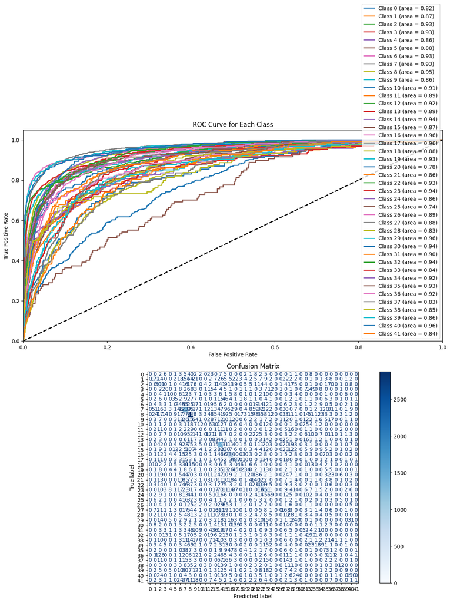

```python
# Generate predictions and probabilities
y_pred_prob = model.predict(X_val_pad)  # Predicted probabilities
y_pred = np.argmax(y_pred_prob, axis=1)  # Predicted classes

# Binarize the output labels for multi-class ROC
y_val_bin = label_binarize(labels_val, classes=[i for i in range(42)])

# Compute ROC curve and ROC area for each class
fpr = {}
tpr = {}
roc_auc = {}

for i in range(42):
    fpr[i], tpr[i], _ = roc_curve(y_val_bin[:, i], y_pred_prob[:, i])
    roc_auc[i] = auc(fpr[i], tpr[i])

# Compute the micro-average ROC curve and AUC
fpr["micro"], tpr["micro"], _ = roc_curve(y_val_bin.ravel(), y_pred_prob.ravel())
roc_auc["micro"] = auc(fpr["micro"], tpr["micro"])

# Plot ROC curve
plt.figure(figsize=(12, 16))  # Adjust the figure size as needed

# Subplot for ROC curve (Top)
plt.subplot(2, 1, 1)
for i in range(42):
    plt.plot(fpr[i], tpr[i], lw=2, label=f'Class {i} (area = {roc_auc[i]:0.2f})')

plt.plot([0, 1], [0, 1], 'k--', lw=2)
plt.xlim([0.0, 1.0])
plt.ylim([0.0, 1.05])
plt.xlabel('False Positive Rate')
plt.ylabel('True Positive Rate')
plt.title('ROC Curve for Each Class')
plt.legend(loc="lower right")

# Subplot for Confusion Matrix (Bottom)
plt.subplot(2, 1, 2)
conf_matrix = confusion_matrix(labels_val, y_pred)
disp = ConfusionMatrixDisplay(confusion_matrix=conf_matrix)
disp.plot(cmap=plt.cm.Blues, values_format='d', ax=plt.gca())
plt.title('Confusion Matrix')

# Show both plots
plt.tight_layout()
plt.show()
```

### **LSTM Architecture**

##### Necessary Data Pre-processing

```python
# Data Preprocessing

# Prepare text data
texts = news['combined_text_no_stopwords'].values
labels = news['trained_labels'].values


# Split data into training and validation sets
texts_train, texts_val, labels_train, labels_val = train_test_split(texts, labels, test_size=0.1, random_state=43)

# Tokenize text data
max_features = 20000
maxlen = 128
tokenizer = Tokenizer(num_words=max_features)
tokenizer.fit_on_texts(texts_train)

X_train = tokenizer.texts_to_sequences(texts_train)
X_val = tokenizer.texts_to_sequences(texts_val)

# Pad sequences to ensure uniform length
X_train_pad = pad_sequences(X_train, maxlen=128)
X_val_pad = pad_sequences(X_val, maxlen=128)

# Convert labels to categorical
y_train_cat = to_categorical(labels_train, num_classes=42)
y_val_cat = to_categorical(labels_val, num_classes=42)
```

- Initially, similarly to the RNN model, we observe the creation of the new column **"combined_text_no_stopwords "**, which as mentioned above contains the title and the short description of each news text after the removal of stopwords, based on which the final categorization of the texts in the category they belong to will be done.
- Then, with the variables **"texts "** and **"labels "** the data of the column "combined_text_no_stopwords" are extracted as well as all labels contained in the dataset, to be used below for model training.
- Subsequently, this is followed by the separation of the above data for training the model and testing it on the validation set.
- Next, the **Tokenization** process is performed, where the token size is set to a limit of 20000 words with a maximum length of 128. Furthermore, the function "tokenizer" is created, which will be used below, and it converts the text containing the tokens into sequences of integers, where each of these integers represents a word, and finally it adapts and integrates the generated tokens into the training sets.
- The **"tokenizer "** function is used to convert the text containing the tokens into sequences of integers, each of these integers representing a word, and assigns them to the **X_train** and **X_val** variables respectively.
- Next, the **"Padding "** procedure follows, where it is ensured that all sequences have the same length by padding them with zeros (or truncating longer sequences) up to the length of maxlen. The generated sequences resulting from the padding process are assigned to the variables **X_train_pad** and **X_val_pad**.
- Finally, a necessary part of the preprocessing of the data for input to the RNN model is the conversion of the data from integer labels to encoded vectors using the **one-hot encoding** technique, which are necessary for classification.

##### LSTM Model Implementation

- It is important to note that the RNN model in this project is a sequential model.
- Initially, the **Embedding Layer** is created which has the ability to convert positive integers (i.e. the sequences of words created in the pre-processing of the data) into dense vectors of fixed size for better use in the model.
- Next, the first base layer **LSTM Layer "** is created, which includes 128 hidden units, meaning that it outputs a vector of size 128 for each time step as well as declaring the RNN to return the full sequence of outputs for each input sequence, not just the last output.
- Next, the first **Dropout Layer** is created, which having a value of **0.5** sets 50% of the inputs as 0. Due to the above property, it performs the necessary normalization to prevent the model from overfitting the training data.
- Next, the second **LSTM Layer** is created, with the main difference from the first LSTM Layer, that it returns only the output at the last time step and not all the outputs, which is then passed to the next layer, namely the second **Dropout Layer** of the model.
- Finally, regarding the architecture of the model, the **Dence Layer** is created, which includes 42 output neurons due to the 42 different classes. Also the use of the activation function **softmax** is made.
- Furthermore, the appropriate conditions, for training the model, are defined. With the function **"loss='categorical_crossentropy'"** the loss function is specified, with the statement of **"optimizer='adam'"** the optimization algorithm Adam' is used, which adjusts the learning rate during training, and finally the accuracy is set as an evaluation measure.

```python
# LSTM model Architecture

# Build the model
model = Sequential()
model.add(Embedding(input_dim=20000, output_dim=128, input_length=128))
model.add(LSTM(128, return_sequences=True))
model.add(Dropout(0.5))
model.add(LSTM(128))
model.add(Dropout(0.5))
model.add(Dense(42, activation='softmax'))

# Compile the model
model.compile(loss='categorical_crossentropy', optimizer='adam', metrics=['accuracy'])

# Train the model
model.fit(X_train_pad, y_train_cat, epochs=10, batch_size=64, validation_split=0.1)

# Evaluate the model
loss, accuracy = model.evaluate(X_val_pad, y_val_cat)
print(f'Test Accuracy: {accuracy}')
```

```
2652/2652 ━━━━━━━━━━━━━━━━━━━━ 1073s 403ms/step - accuracy: 0.3631 - loss: 2.5221 - val_accuracy: 0.5766 - val_loss: 1.5806
2652/2652 ━━━━━━━━━━━━━━━━━━━━ 1159s 437ms/step - accuracy: 0.6085 - loss: 1.4759 - val_accuracy: 0.6073 - val_loss: 1.4442
2652/2652 ━━━━━━━━━━━━━━━━━━━━ 1166s 439ms/step - accuracy: 0.6651 - loss: 1.2316 - val_accuracy: 0.6160 - val_loss: 1.4152
2652/2652 ━━━━━━━━━━━━━━━━━━━━ 1176s 444ms/step - accuracy: 0.7013 - loss: 1.0816 - val_accuracy: 0.6125 - val_loss: 1.4624
2652/2652 ━━━━━━━━━━━━━━━━━━━━ 1181s 445ms/step - accuracy: 0.7323 - loss: 0.9552 - val_accuracy: 0.6149 - val_loss: 1.5059
2652/2652 ━━━━━━━━━━━━━━━━━━━━ 1190s 449ms/step - accuracy: 0.7615 - loss: 0.8431 - val_accuracy: 0.6023 - val_loss: 1.6108
2652/2652 ━━━━━━━━━━━━━━━━━━━━ 1221s 460ms/step - accuracy: 0.7895 - loss: 0.7428 - val_accuracy: 0.6020 - val_loss: 1.6661
2652/2652 ━━━━━━━━━━━━━━━━━━━━ 1197s 451ms/step - accuracy: 0.8150 - loss: 0.6444 - val_accuracy: 0.5980 - val_loss: 1.7995
2652/2652 ━━━━━━━━━━━━━━━━━━━━ 1220s 460ms/step - accuracy: 0.8375 - loss: 0.5640 - val_accuracy: 0.5892 - val_loss: 1.9957
2652/2652 ━━━━━━━━━━━━━━━━━━━━ 1220s 459ms/step - accuracy: 0.8574 - loss: 0.4988 - val_accuracy: 0.5809 - val_loss: 2.1050
655/655 ━━━━━━━━━━━━━━━━━━━━ 64s 97ms/step - accuracy: 0.5840 - loss: 2.0716
Test Accuracy: 0.5812055468559265
```

Based on the above **result**, the performance of the LSTM model, after the 10 seasons, is concluded with **accuracy of 58%**.

##### ROC Curve and Confusion Matrix Construction

```
655/655 ━━━━━━━━━━━━━━━━━━━━ 67s 102ms/step
```

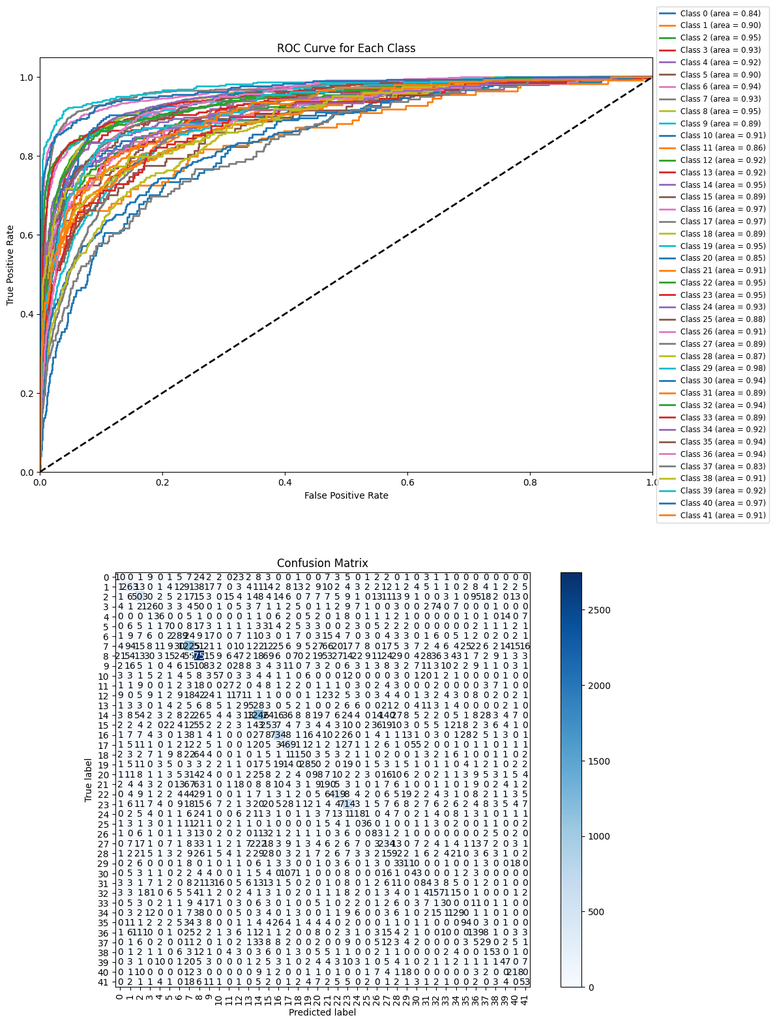

```python
y_score = model.predict(X_val_pad)

# Binarize the labels for multi-class ROC
y_test_binarized = label_binarize(labels_val, classes=np.arange(y_val_cat.shape[1]))
n_classes = y_test_binarized.shape[1]

# Compute ROC curve and ROC area for each class
fpr = dict()
tpr = dict()
roc_auc = dict()
for i in range(n_classes):
    fpr[i], tpr[i], _ = roc_curve(y_test_binarized[:, i], y_score[:, i])
    roc_auc[i] = auc(fpr[i], tpr[i])

# Plot ROC curve
plt.figure(figsize=(12, 16))
plt.subplot(2, 1, 1)  # Two rows, one column, first subplot
for i in range(n_classes):
    plt.plot(fpr[i], tpr[i], lw=2, label=f'Class {i} (area = {roc_auc[i]:.2f})')
plt.plot([0, 1], [0, 1], 'k--', lw=2)
plt.xlim([0.0, 1.0])
plt.ylim([0.0, 1.05])
plt.xlabel('False Positive Rate')
plt.ylabel('True Positive Rate')
plt.title('ROC Curve for Each Class')
plt.legend(loc="center left", bbox_to_anchor=(1, 0.5), fontsize='small')

# Convert categorical labels back to integer labels for confusion matrix
y_pred = np.argmax(y_score, axis=1)
y_true = np.argmax(y_test_binarized, axis=1)

# Confusion Matrix
cm = confusion_matrix(y_true, y_pred)

plt.subplot(2, 1, 2)  # Two rows, one column, second subplot
plt.imshow(cm, interpolation='nearest', cmap=plt.cm.Blues)
plt.title('Confusion Matrix')
plt.colorbar()
tick_marks = np.arange(y_val_cat.shape[1])
plt.xticks(tick_marks, tick_marks, rotation=90)
plt.yticks(tick_marks, tick_marks)

# Add text annotations in confusion matrix
thresh = cm.max() / 2.
for i, j in np.ndindex(cm.shape):
    plt.text(j, i, format(cm[i, j], 'd'),
             ha="center", va="center",
             color="white" if cm[i, j] > thresh else "black")

plt.tight_layout()
plt.ylabel('True label')
plt.xlabel('Predicted label')

plt.show()
```

### **Naive Bayes and TF/IDF Architecture**

##### Necessary Data Pre-processing

```python
# Encode Labels
label_encoder = LabelEncoder()
news['labels'] = label_encoder.fit_transform(news['category'])

# Split the dataset into training and testing sets
X_train, X_test, y_train, y_test = train_test_split(news['combined_text_no_stopwords'], news['labels'], test_size=0.2, random_state=42)

# Initialize TF-IDF Vectorizer
tfidf = TfidfVectorizer(max_features=2000, ngram_range=(1, 2)) # Converts text documents into a matrix of TF-IDF features. ςηιλε αλσο #Considers both unigrams (single words) and bigrams (two-word combinations) in the text.

# Fit and transform the training data
X_train_tfidf = tfidf.fit_transform(X_train)
X_test_tfidf = tfidf.transform(X_test)
```

- Initially, the **"label_encoder "** function is used to convert the categorical data in the "labels" column into numeric labels, which are then re-stored in the "labels" column. This conversion is necessary for the processing of the data by the Naive Bayes classifier.
- Then, similarly to the previous two architectures, the description data of each news item, from which the stopwords have been extracted, as well as the new numeric labels, are separated for the test and validation set, for model training.
- Subsequently, using the **"TfidfVectorizer "** function, the categorical description data of each news item, i.e. the data in the column "combined_text_no_stopwords" is converted into TF-IDF numeric attributes.

##### Naive Bayes Implementation

- Important to mention, regarding the architecture of the model, is the use of the Multinomial Naive Bayes Classifier.
- Subsequently, the training of the classifier follows. The "x_train_tfidf" argument is the table of TF-IDF features and the "y_train" argument contains the corresponding labels for these features.
- Finally, once the Naive Bayes training is finished, it is tested to predict the labels of the test data. The "X_test_tfidf" argument is the TF-IDF table of the test set. All predictions are stored in the variable "y_pred".

```python
# Initialize the Naive Bayes classifier
nb_model = MultinomialNB()

# Train the model
nb_model.fit(X_train_tfidf, y_train)

# Make predictions on the test set
y_pred = nb_model.predict(X_test_tfidf)

# Evaluate the model
accuracy = accuracy_score(y_test, y_pred)
print(f'Test Accuracy: {accuracy}')
```

```
Test Accuracy: 0.4806710256287882
```

Based on the above **result**, the performance of the Naive Bayes classifier is concluded with **accuracy of 48%**.

##### ROC Curve and Confusion Matrix Construction

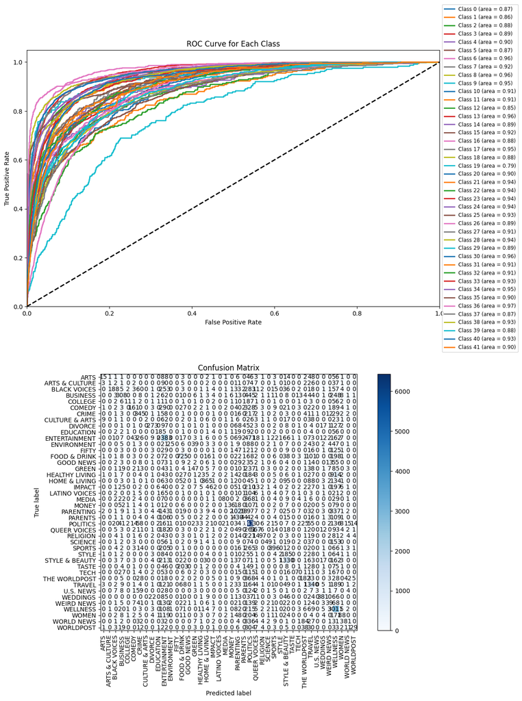

```python
# Assuming you have already trained your Naive Bayes classifier (nb_model) and have X_test_tfidf, y_test

# Binarize the labels for multi-class ROC
y_test_binarized = label_binarize(y_test, classes=np.arange(len(label_encoder.classes_)))
n_classes = y_test_binarized.shape[1]

# OneVsRestClassifier to handle multi-class case
ovr_classifier = OneVsRestClassifier(nb_model)
y_score = ovr_classifier.fit(X_train_tfidf, y_train).predict_proba(X_test_tfidf)

# Compute ROC curve and ROC area for each class
fpr = dict()
tpr = dict()
roc_auc = dict()
for i in range(n_classes):
    fpr[i], tpr[i], _ = roc_curve(y_test_binarized[:, i], y_score[:, i])
    roc_auc[i] = auc(fpr[i], tpr[i])

# Plot ROC curve
plt.figure(figsize=(12, 16))
plt.subplot(2, 1, 1)  # Two rows, one column, first subplot
for i in range(n_classes):
    plt.plot(fpr[i], tpr[i], lw=2, label=f'Class {i} (area = {roc_auc[i]:.2f})')
plt.plot([0, 1], [0, 1], 'k--', lw=2)
plt.xlim([0.0, 1.0])
plt.ylim([0.0, 1.05])
plt.xlabel('False Positive Rate')
plt.ylabel('True Positive Rate')
plt.title('ROC Curve for Each Class')
plt.legend(loc="center left", bbox_to_anchor=(1, 0.5), fontsize='small')

# Confusion Matrix
cm = confusion_matrix(y_test, y_pred)

plt.subplot(2, 1, 2)  # Two rows, one column, second subplot
plt.imshow(cm, interpolation='nearest', cmap=plt.cm.Blues)
plt.title('Confusion Matrix')
plt.colorbar()
tick_marks = np.arange(len(label_encoder.classes_))
plt.xticks(tick_marks, label_encoder.classes_, rotation=90)
plt.yticks(tick_marks, label_encoder.classes_)

# Add text annotations in confusion matrix
thresh = cm.max() / 2.
for i, j in np.ndindex(cm.shape):
    plt.text(j, i, format(cm[i, j], 'd'),
             ha="center", va="center",
             color="white" if cm[i, j] > thresh else "black")

plt.tight_layout()
plt.ylabel('True label')
plt.xlabel('Predicted label')

plt.show()
```

### **Section II: Testing Models without removing Stop Words**

### **RNN Architecture**

##### Necessary Data Pre-processing

```python
# Data Preprocessing

texts = news['combined_text'].values  # Using the original 'combined_text' without removing stopwords
labels = news['trained_labels'].values

# Split data into training and validation sets
texts_train, texts_val, labels_train, labels_val = train_test_split(texts, labels, test_size=0.1, random_state=43)

# Tokenize text data
max_features = 20000
maxlen = 128
tokenizer = Tokenizer(num_words=max_features)
tokenizer.fit_on_texts(texts_train)

X_train = tokenizer.texts_to_sequences(texts_train)
X_val = tokenizer.texts_to_sequences(texts_val)

# Pad sequences to ensure uniform length
X_train_pad = pad_sequences(X_train, maxlen=maxlen)
X_val_pad = pad_sequences(X_val, maxlen=maxlen)

# Convert labels to categorical
y_train_cat = to_categorical(labels_train, num_classes=42)
y_val_cat = to_categorical(labels_val, num_classes=42)
```

##### RNN Model Implementation

*It is important to note that the RNN model in this paper is a sequential model.

- Initially, the **Embedding Layer** is created which has the ability to convert positive integers (i.e. the sequences of words created in the pre-processing of the data) into dense vectors of fixed size for better use in the model.
- Next, the first base layer **SimpleRNN Layer "** is created, which includes 128 hidden units, meaning that it outputs a vector of size 128 for each time step as well as declaring the RNN to return the full sequence of outputs for each input sequence, not just the last output.
- Next, the first **Dropout Layer** is created, which having a value of **0.5** sets 50% of the inputs as 0. Due to the above property, it performs the necessary normalization to prevent the model from overfitting the training data.
- Next, the second **SimpleRNN Layer** is created, with the main difference from the first SimpleRNN Layer, that it returns only the output at the last time step and not all the outputs, which is then passed to the next layer, i.e. the second **Dropout Layer** of the model.
- Finally, regarding the architecture of the model, the **Dence Layer** is created, which includes 42 output neurons, due to the 42 different classes. Also the use of the activation function **softmax** is made.
- Furthermore, the appropriate conditions, for training the model, are defined. With the function **"loss='categorical_crossentropy'"** the loss function is specified, with the statement of **"optimizer='adam'"** the optimization algorithm Adam' is used, which adjusts the learning rate during training, and finally the accuracy is set as an evaluation measure.

```python
# Build the RNN model

model = Sequential()
model.add(Embedding(input_dim=max_features, output_dim=128, input_length=maxlen))
model.add(SimpleRNN(128, return_sequences=True))  # First RNN layer with 128 units
model.add(Dropout(0.5))  # Dropout for regularization
model.add(SimpleRNN(128))  # Second RNN layer with 128 units
model.add(Dropout(0.5))  # Dropout for regularization
model.add(Dense(42, activation='softmax'))  # Output layer with softmax activation

# Compile the model
model.compile(loss='categorical_crossentropy', optimizer='adam', metrics=['accuracy'])

# Train the model
model.fit(X_train_pad, y_train_cat, epochs=10, batch_size=64, validation_split=0.1)

# Evaluate the model
loss, accuracy = model.evaluate(X_val_pad, y_val_cat)
print(f'Test Accuracy: {accuracy}')
```

```
2652/2652 ━━━━━━━━━━━━━━━━━━━━ 386s 144ms/step - accuracy: 0.2572 - loss: 2.9705 - val_accuracy: 0.3632 - val_loss: 2.5111
2652/2652 ━━━━━━━━━━━━━━━━━━━━ 396s 149ms/step - accuracy: 0.3745 - loss: 2.4583 - val_accuracy: 0.3972 - val_loss: 2.4305
2652/2652 ━━━━━━━━━━━━━━━━━━━━ 385s 145ms/step - accuracy: 0.3859 - loss: 2.4027 - val_accuracy: 0.3898 - val_loss: 2.3888
2652/2652 ━━━━━━━━━━━━━━━━━━━━ 442s 145ms/step - accuracy: 0.3635 - loss: 2.5168 - val_accuracy: 0.3920 - val_loss: 2.3811
2652/2652 ━━━━━━━━━━━━━━━━━━━━ 443s 146ms/step - accuracy: 0.3728 - loss: 2.4646 - val_accuracy: 0.3515 - val_loss: 2.5284
2652/2652 ━━━━━━━━━━━━━━━━━━━━ 444s 147ms/step - accuracy: 0.3952 - loss: 2.3650 - val_accuracy: 0.3981 - val_loss: 2.3880
2652/2652 ━━━━━━━━━━━━━━━━━━━━ 441s 146ms/step - accuracy: 0.4091 - loss: 2.3257 - val_accuracy: 0.3123 - val_loss: 2.7654
2652/2652 ━━━━━━━━━━━━━━━━━━━━ 391s 148ms/step - accuracy: 0.3302 - loss: 2.6433 - val_accuracy: 0.3648 - val_loss: 2.4764
2652/2652 ━━━━━━━━━━━━━━━━━━━━ 389s 147ms/step - accuracy: 0.3779 - loss: 2.4415 - val_accuracy: 0.3947 - val_loss: 2.3314
2652/2652 ━━━━━━━━━━━━━━━━━━━━ 443s 147ms/step - accuracy: 0.4059 - loss: 2.3304 - val_accuracy: 0.4031 - val_loss: 2.3107
655/655 ━━━━━━━━━━━━━━━━━━━━ 18s 28ms/step - accuracy: 0.4100 - loss: 2.3016
Test Accuracy: 0.40552666783332825
```

Based on the above **result** the performance of the RNN model, after the 10 seasons, is concluded with **accuracy of 40%**.

##### ROC Curve and Confusion Matrix Construction

```
655/655 ━━━━━━━━━━━━━━━━━━━━ 19s 29ms/step
```

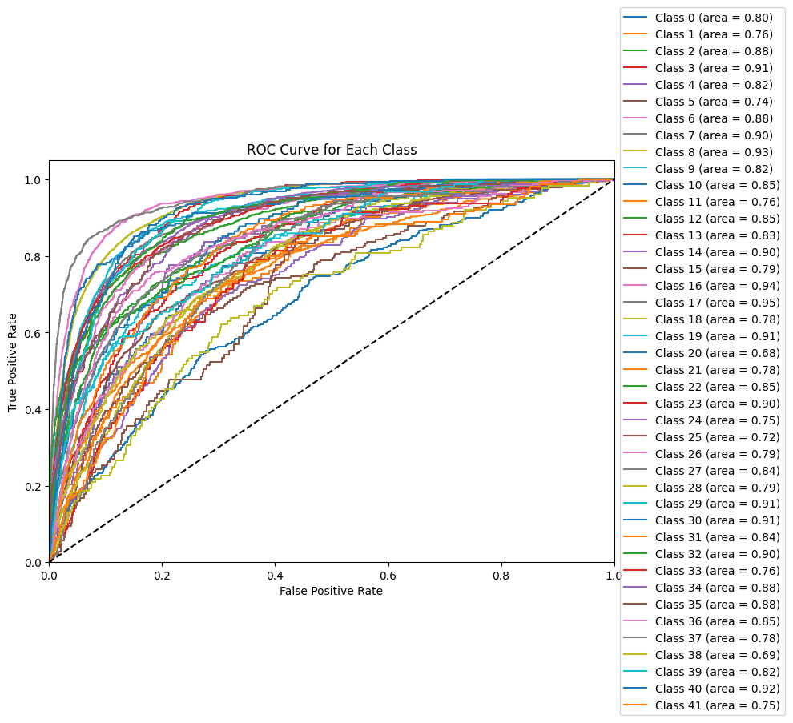

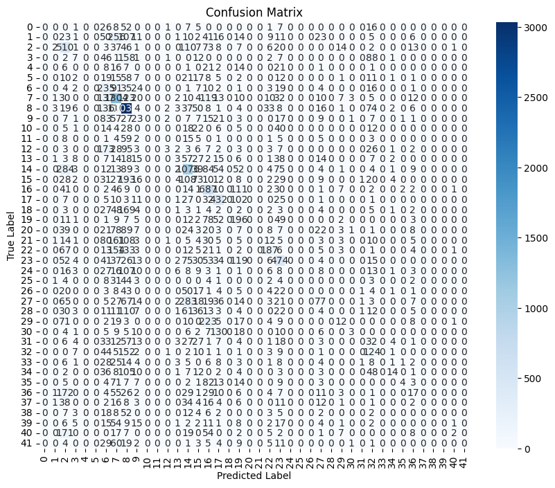

```python
# Make predictions on the validation set
y_val_pred = model.predict(X_val_pad)

# Binarize the labels for ROC curve (one-hot encoding)
y_val_binarized = label_binarize(labels_val, classes=range(42))

# Compute ROC curve and ROC area for each class
fpr = dict()
tpr = dict()
roc_auc = dict()
for i in range(42):
    fpr[i], tpr[i], _ = roc_curve(y_val_binarized[:, i], y_val_pred[:, i])
    roc_auc[i] = auc(fpr[i], tpr[i])

# Plot ROC curve for each class
plt.figure(figsize=(10, 8))
for i in range(42):
    plt.plot(fpr[i], tpr[i], label=f'Class {i} (area = {roc_auc[i]:.2f})')
plt.plot([0, 1], [0, 1], 'k--')
plt.xlim([0.0, 1.0])
plt.ylim([0.0, 1.05])
plt.xlabel('False Positive Rate')
plt.ylabel('True Positive Rate')
plt.title('ROC Curve for Each Class')
plt.legend(loc='center left', bbox_to_anchor=(1, 0.5))
plt.tight_layout()

# Confusion Matrix
y_val_pred_classes = y_val_pred.argmax(axis=1)
conf_matrix = confusion_matrix(labels_val, y_val_pred_classes)

# Plot Confusion Matrix
plt.figure(figsize=(10, 8))
sns.heatmap(conf_matrix, annot=True, fmt='d', cmap='Blues', xticklabels=range(42), yticklabels=range(42))
plt.xlabel('Predicted Label')
plt.ylabel('True Label')
plt.title('Confusion Matrix')
plt.show()
```

It is additionally observed that similarly in the 1st approach with the removal of stopwords, the RNN model one of the classes that did not predict well was class 25 (== LATINO VOICES).

### **LSTM Architecture**

##### Necessary Data Pre-processing

```python
# Data Preprocessing

texts = news['combined_text'].values  # Using the original 'combined_text' without removing stopwords
labels = news['trained_labels'].values

# Split data into training and validation sets
texts_train, texts_val, labels_train, labels_val = train_test_split(texts, labels, test_size=0.1, random_state=43)

# Tokenize text data
max_features = 20000
maxlen = 128
tokenizer = Tokenizer(num_words=max_features)
tokenizer.fit_on_texts(texts_train)

X_train = tokenizer.texts_to_sequences(texts_train)
X_val = tokenizer.texts_to_sequences(texts_val)

# Pad sequences to ensure uniform length
X_train_pad = pad_sequences(X_train, maxlen=maxlen)
X_val_pad = pad_sequences(X_val, maxlen=maxlen)

# Convert labels to categorical
y_train_cat = to_categorical(labels_train, num_classes=42)
y_val_cat = to_categorical(labels_val, num_classes=42)
```

- Initially, similarly to the RNN model, we observe the creation of the new column **"combined_text "**, which as mentioned above contains the title and the short description of each news text as it is without the removal of stopwords, on the basis of which the final categorization of the texts in the category they belong to will be done.
- Then, with the variables **"texts "** and **"labels "** the data of the column "combined_text" are extracted as well as all labels contained in the dataset, to be used below for model training.
- Subsequently, this is followed by the separation of the above data for training the model and testing it on the validation set.
- Next, the **Tokenization** process is performed, where the token size is set to a limit of 20000 words with a maximum length of 128. Furthermore, the function "tokenizer" is created, which will be used below, and it converts the text containing the tokens into sequences of integers, where each of these integers represents a word, and finally it adapts and integrates the generated tokens into the training sets.
- The **"tokenizer "** function is used to convert the text containing the tokens into sequences of integers, each of these integers representing a word, and assigns them to the **X_train** and **X_val** variables respectively.
- Next, the **"Padding "** procedure follows, where it is ensured that all sequences have the same length by padding them with zeros (or truncating longer sequences) up to the length of maxlen. The generated sequences resulting from the padding process are assigned to the variables **X_train_pad** and **X_val_pad**.
- Finally, a necessary part of the preprocessing of the data for input to the RNN model is the conversion of the data from integer labels to encoded vectors using the **one-hot encoding** technique, which are necessary for classification.

##### LSTM Model Implementation

*It is important to note that the RNN model in this paper is a sequential model.

- Initially, the **Embedding Layer** is created which has the ability to convert positive integers (i.e. the sequences of words created in the pre-processing of the data) into dense vectors of fixed size for better use in the model.
- Next, the first base layer **LSTM Layer "** is created, which includes 128 hidden units, meaning that it outputs a vector of size 128 for each time step as well as declaring the RNN to return the full sequence of outputs for each input sequence, not just the last output.
- Next, the first **Dropout Layer** is created, which having a value of **0.5** sets 50% of the inputs as 0. Due to the above property, it performs the necessary normalization to prevent the model from overfitting the training data.
- Next, the second **LSTM Layer** is created, with the main difference from the first LSTM Layer, that it returns only the output at the last time step and not all the outputs, which is then passed to the next layer, namely the second **Dropout Layer** of the model.
- Finally, regarding the architecture of the model, the **Dence Layer** is created, which includes 42 output neurons due to the 42 different classes. Also the use of the activation function **softmax** is made.
- Furthermore, the appropriate conditions, for training the model, are defined. With the function **"loss='categorical_crossentropy'"** the loss function is specified, with the statement of **"optimizer='adam'"** the optimization algorithm Adam' is used, which adjusts the learning rate during training, and finally the accuracy is set as an evaluation measure.

```python
# Build the LSTM model

model = Sequential()
model.add(Embedding(input_dim=max_features, output_dim=128, input_length=maxlen))
model.add(LSTM(128, return_sequences=True))  # First LSTM layer with 128 units
model.add(Dropout(0.5))  # Dropout for regularization
model.add(LSTM(128))  # Second LSTM layer with 128 units
model.add(Dropout(0.5))  # Dropout for regularization
model.add(Dense(42, activation='softmax'))  # Output layer with softmax activation

# Compile the model
model.compile(loss='categorical_crossentropy', optimizer='adam', metrics=['accuracy'])

# Train the model
model.fit(X_train_pad, y_train_cat, epochs=10, batch_size=64, validation_split=0.1)

# Evaluate the model
loss, accuracy = model.evaluate(X_val_pad, y_val_cat)
print(f'Test Accuracy: {accuracy}')
```

```
2652/2652 ━━━━━━━━━━━━━━━━━━━━ 1312s 492ms/step - accuracy: 0.3496 - loss: 2.5703 - val_accuracy: 0.5583 - val_loss: 1.6536
2652/2652 ━━━━━━━━━━━━━━━━━━━━ 1318s 497ms/step - accuracy: 0.5876 - loss: 1.5595 - val_accuracy: 0.6023 - val_loss: 1.4754
2652/2652 ━━━━━━━━━━━━━━━━━━━━ 1335s 494ms/step - accuracy: 0.6487 - loss: 1.2908 - val_accuracy: 0.6158 - val_loss: 1.4109
2652/2652 ━━━━━━━━━━━━━━━━━━━━ 1324s 499ms/step - accuracy: 0.6871 - loss: 1.1359 - val_accuracy: 0.6225 - val_loss: 1.4039
2652/2652 ━━━━━━━━━━━━━━━━━━━━ 1339s 498ms/step - accuracy: 0.7212 - loss: 0.9984 - val_accuracy: 0.6189 - val_loss: 1.4404
2652/2652 ━━━━━━━━━━━━━━━━━━━━ 1334s 503ms/step - accuracy: 0.7530 - loss: 0.8822 - val_accuracy: 0.6201 - val_loss: 1.4930
2652/2652 ━━━━━━━━━━━━━━━━━━━━ 1438s 542ms/step - accuracy: 0.7782 - loss: 0.7809 - val_accuracy: 0.6150 - val_loss: 1.5741
2652/2652 ━━━━━━━━━━━━━━━━━━━━ 1507s 559ms/step - accuracy: 0.8031 - loss: 0.6916 - val_accuracy: 0.6078 - val_loss: 1.6931
2652/2652 ━━━━━━━━━━━━━━━━━━━━ 1493s 563ms/step - accuracy: 0.8273 - loss: 0.6046 - val_accuracy: 0.5977 - val_loss: 1.7893
2652/2652 ━━━━━━━━━━━━━━━━━━━━ 1513s 571ms/step - accuracy: 0.8510 - loss: 0.5295 - val_accuracy: 0.5979 - val_loss: 1.9059
655/655 ━━━━━━━━━━━━━━━━━━━━ 67s 102ms/step - accuracy: 0.5929 - loss: 1.9044
Test Accuracy: 0.5904643535614014
```

Based on the above **result** the performance of the LSTM model, after the 10 seasons, is concluded with an **accuracy of 59%**.

##### ROC Curve and Confusion Matrix Construction

```
655/655 ━━━━━━━━━━━━━━━━━━━━ 67s 101ms/step
```

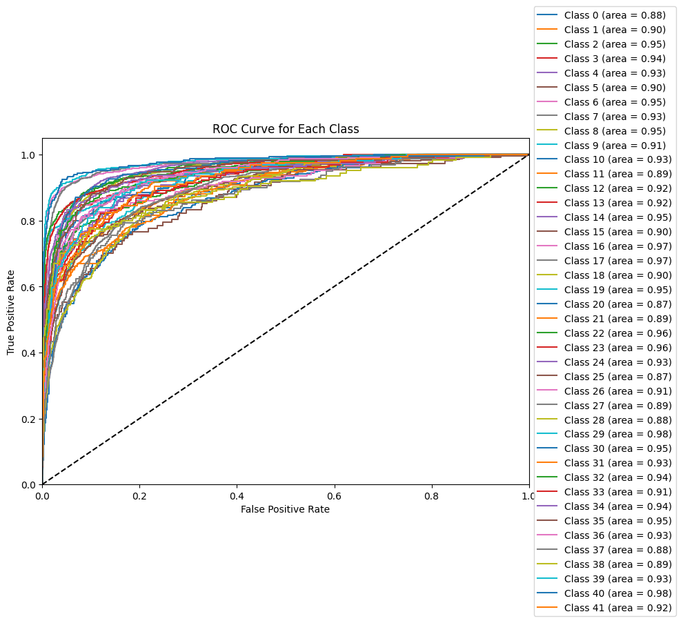

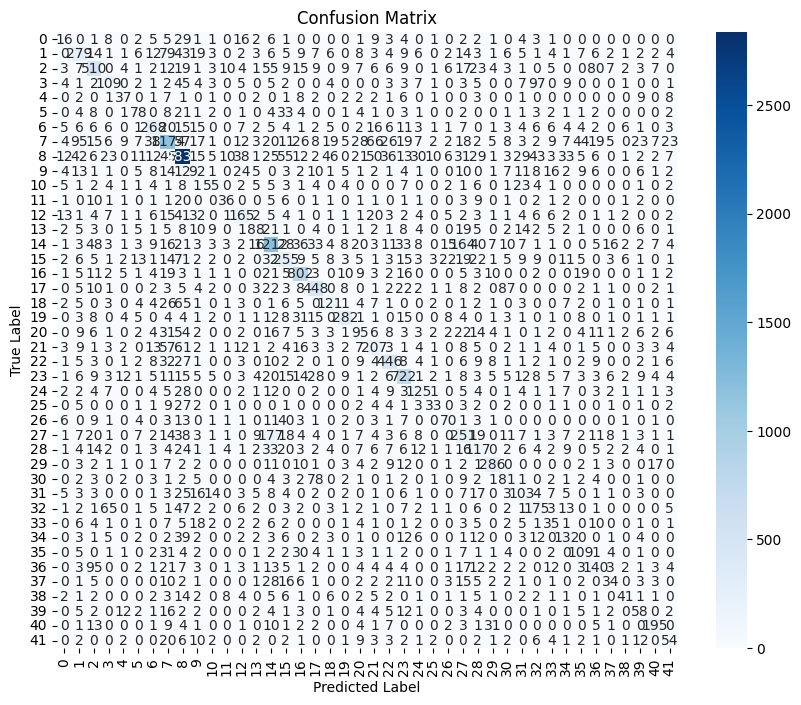

```python
# Make predictions on the validation set
y_val_pred = model.predict(X_val_pad)

# Binarize the labels for ROC curve (one-hot encoding)
y_val_binarized = label_binarize(labels_val, classes=range(42))

# Compute ROC curve and ROC area for each class
fpr = dict()
tpr = dict()
roc_auc = dict()
for i in range(42):
    fpr[i], tpr[i], _ = roc_curve(y_val_binarized[:, i], y_val_pred[:, i])
    roc_auc[i] = auc(fpr[i], tpr[i])

# Plot ROC curve for each class
plt.figure(figsize=(10, 8))
for i in range(42):
    plt.plot(fpr[i], tpr[i], label=f'Class {i} (area = {roc_auc[i]:.2f})')
plt.plot([0, 1], [0, 1], 'k--')
plt.xlim([0.0, 1.0])
plt.ylim([0.0, 1.05])
plt.xlabel('False Positive Rate')
plt.ylabel('True Positive Rate')
plt.title('ROC Curve for Each Class')
plt.legend(loc='center left', bbox_to_anchor=(1, 0.5))
plt.tight_layout()

# Confusion Matrix
y_val_pred_classes = y_val_pred.argmax(axis=1)
conf_matrix = confusion_matrix(labels_val, y_val_pred_classes)

# Plot Confusion Matrix
plt.figure(figsize=(10, 8))
sns.heatmap(conf_matrix, annot=True, fmt='d', cmap='Blues', xticklabels=range(42), yticklabels=range(42))
plt.xlabel('Predicted Label')
plt.ylabel('True Label')
plt.title('Confusion Matrix')
plt.show()
```

### **Naive Bayes and TF/IDF Architecture**

##### Necessary Data Pre-processing

```python
# Data Preprocessing

texts = news['combined_text'].values  # Using the original 'combined_text' without removing stopwords
labels = news['trained_labels'].values

# Split data into training and validation sets
texts_train, texts_val, labels_train, labels_val = train_test_split(texts, labels, test_size=0.1, random_state=43)

# Vectorize the text data using TF-IDF
max_features = 20000
tfidf = TfidfVectorizer(max_features=max_features)

X_train_tfidf = tfidf.fit_transform(texts_train)
X_val_tfidf = tfidf.transform(texts_val)
```

##### Naive Bayes Implementation

```python
# Build the Naive Bayes model
model_nb = MultinomialNB()

# Train the model
model_nb.fit(X_train_tfidf, labels_train)

# Evaluate the model
accuracy = model_nb.score(X_val_tfidf, labels_val)
print(f'Test Accuracy: {accuracy}')
```

```
Test Accuracy: 0.49057414212761896
```

##### ROC Curve and Confusion Matrix Construction

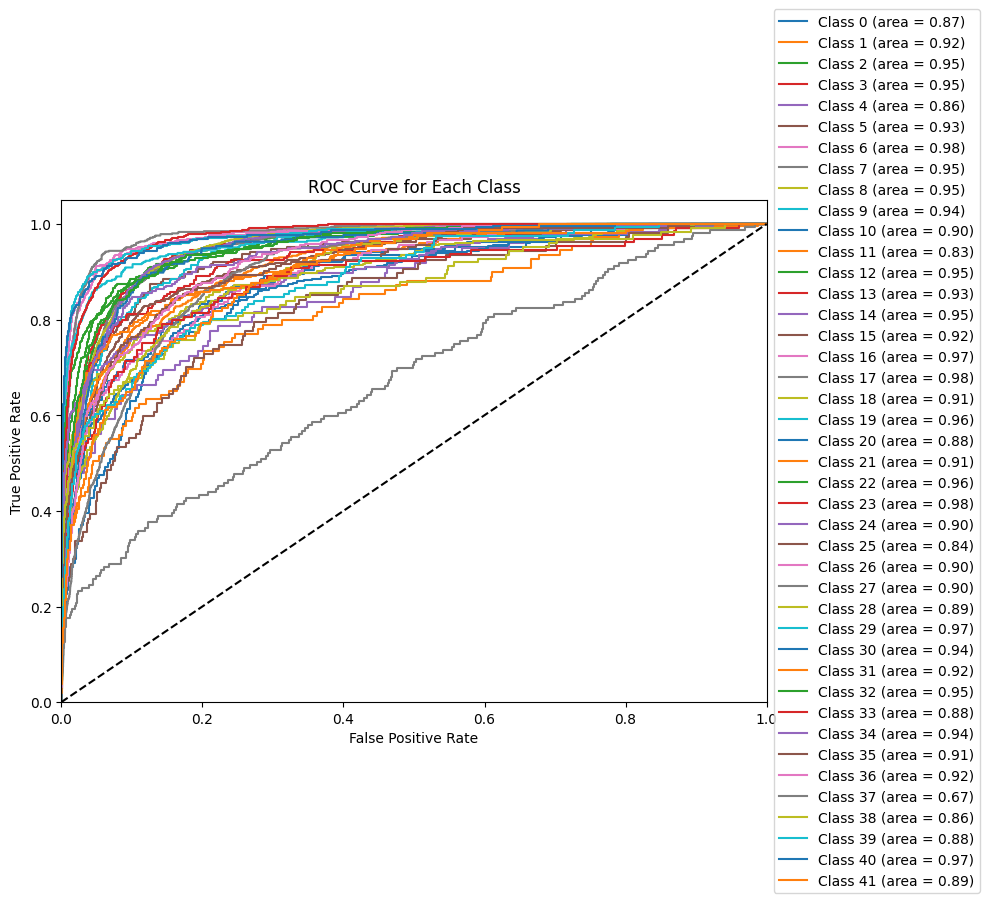

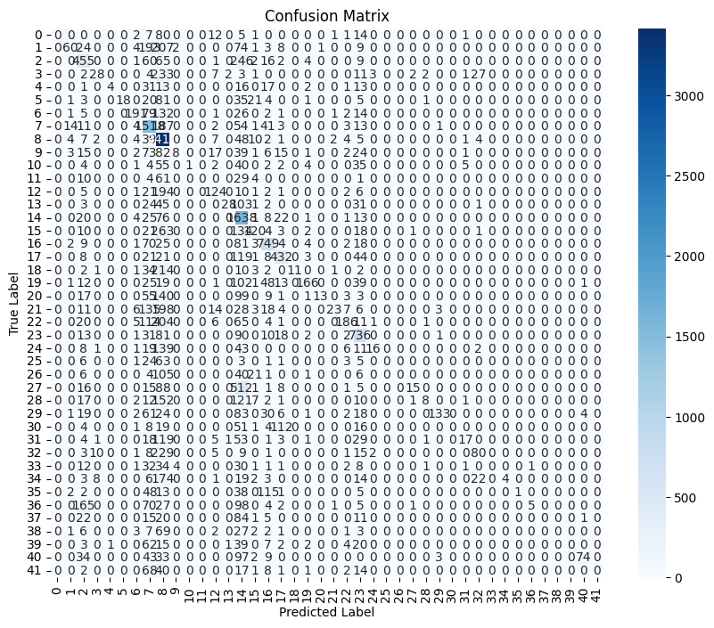

```python
# Make predictions on the validation set
y_val_pred = model_nb.predict_proba(X_val_tfidf)

# Binarize the labels for ROC curve (one-hot encoding)
y_val_binarized = label_binarize(labels_val, classes=range(42))

# Compute ROC curve and ROC area for each class
fpr = dict()
tpr = dict()
roc_auc = dict()
for i in range(42):
    fpr[i], tpr[i], _ = roc_curve(y_val_binarized[:, i], y_val_pred[:, i])
    roc_auc[i] = auc(fpr[i], tpr[i])

# Plot ROC curve for each class
plt.figure(figsize=(10, 8))
for i in range(42):
    plt.plot(fpr[i], tpr[i], label=f'Class {i} (area = {roc_auc[i]:.2f})')
plt.plot([0, 1], [0, 1], 'k--')
plt.xlim([0.0, 1.0])
plt.ylim([0.0, 1.05])
plt.xlabel('False Positive Rate')
plt.ylabel('True Positive Rate')
plt.title('ROC Curve for Each Class')
plt.legend(loc='center left', bbox_to_anchor=(1, 0.5))
plt.tight_layout()

# Confusion Matrix
y_val_pred_classes = model_nb.predict(X_val_tfidf)
conf_matrix = confusion_matrix(labels_val, y_val_pred_classes)

# Plot Confusion Matrix
plt.figure(figsize=(10, 8))
sns.heatmap(conf_matrix, annot=True, fmt='d', cmap='Blues', xticklabels=range(42), yticklabels=range(42))
plt.xlabel('Predicted Label')
plt.ylabel('True Label')
plt.title('Confusion Matrix')
plt.show()
```

### **Conclusions**

In the context of this thesis, some of the most well-known and widely used neural network architectures in text classification problems were implemented. The aim of this work was to predict and classify the textual data as efficiently and accurately as possible, based on their title and short description, in one of the 42 existing and given categories of the dataset used. Overall, based on the above data, important conclusions are conducted on the performance of the three neural network architectures as well as the two approaches, by removing ,i.e., stopwords and keeping the text data unchanged from the dataset.

### **Bibliography**

[1] Tasoulis, S. (2024). Notes for the course Deep Learning. University of Thessaly. Lamia

[2] Tasoulis, S. (2024). Notes for the course Mining and Analysis of Large Volume Data. University of Thessaly. Lamia

[3] Ahmad, P. N., Shah, A. M., & Lee, K. (2023). A review on Electronic Health Record Text-Mining for biomedical name entity recognition in healthcare domain. Healthcare, 11(9), 1268. https://doi.org/10.3390/healthcare11091268

[4] Hassan, E., El-Hafeez, T. A., & Shams, M. Y. (2024). Optimizing classification of diseases through language model analysis of symptoms. Scientific Reports, 14(1). https://doi.org/10.1038/s41598-024-51615-5

[5] Edara, D. C., Vanukuri, L. P., Sistla, V., & Kolli, V. K. K. (2019b). Sentiment analysis and text categorization of cancer medical records with LSTM. Journal of Ambient Intelligence & Humanized Computing/Journal of Ambient Intelligence and Humanized Computing, 14(5), 5309–5325. https://doi.org/10.1007/s12652-019-01399-8

[6] Botlagunta, M., Botlagunta, M. D., Myneni, M. B., Lakshmi, D., Nayyar, A., Gullapalli, J. S., & Shah, M. A. (2023). Classification and diagnostic prediction of breast cancer metastasis on clinical data using machine learning algorithms. Scientific Reports, 13(1). https://doi.org/10.1038/s41598-023-27548-w

[7] Zhang, Q., Guo, Z., Zhu, Y., Vijayakumar, P., Castiglione, A., & Gupta, B. B. (2023). A deep learning-based fast fake news detection model for Cyber-Physical social services. Pattern Recognition Letters, 168, 31–38. https://doi.org/10.1016/j.patrec.2023.02.026

[8] Capuano, N., Fenza, G., Loia, V., & Nota, F. D. (2023). Content-Based Fake News Detection With Machine and Deep Learning: a Systematic Review. Neurocomputing, 530, 91–103. https://doi.org/10.1016/j.neucom.2023.02.005

[9] Osnabrügge, M., Ash, E., & Morelli, M. (2021). Cross-Domain topic classification for political texts. Political Analysis, 31(1), 59–80. https://doi.org/10.1017/pan.2021.37

[10] Ali, M., Hassan, M., Kifayat, K., Kim, J. Y., Hakak, S., & Khan, M. K. (2023). Social media content classification and community detection using deep learning and graph analytics. Technological Forecasting & Social Change/Technological Forecasting and Social Change, 188, 122252. https://doi.org/10.1016/j.techfore.2022.122252

[11] Wadud, M. a. H., Mridha, M. F., Shin, J., Nur, K., & Saha, A. K. (2023). Deep-BERT: Transfer learning for classifying multilingual offensive texts on social media. Computer Systems Science and Engineering, 44(2), 1775–1791. https://doi.org/10.32604/csse.2023.027841

[12] Kanan, T., Mughaid, A., Al-Shalabi, R., Al-Ayyoub, M., Elbes, M., & Sadaqa, O. (2022). Business intelligence using deep learning techniques for social media contents. Cluster Computing, 26(2), 1285–1296. https://doi.org/10.1007/s10586-022-03626-y

[13] Vaswani, A., Shazeer, N., Parmar, N., Uszkoreit, J., Jones, L., Gomez, A. N., Kaiser, L., & Polosukhin, I. (2017). Attention is all you need. arXiv (Cornell University). https://doi.org/10.48550/arxiv.1706.03762

[14] Website Reference: GeeksforGeeks. (n.d.). GeeksforGeeks | A computer science portal for geeks. https://www.geeksforgeeks.org/